# Project: Investigate a Dataset - TMDB Movie Data Analysis

- Introduction
- Data Wrangling
- Exploratory Data Analysis
- Question 1
- Question 2 (With Scatter Plot)
- Question 2 (With Bar Charts)
- Conclusions
- Limitations

## Introduction

### Dataset Description

I selected the **TMDB Movie** data set.

The data set I've picked contains information about 10,000 movies collected from The Movie Database (TMDb), including user ratings and revenue. In this report, I'll be wrangling and analyzing the the tmdb data set.

The data set has two columns for budget and revenue. The second columns for each are the adjusted values in terms of 2010 dollars accounting for inflation over time.

The data set also has three columns with delimiters "|" that seperates various values.

Further description of the dataset and the questions I'll be answering are immediately after the first 5 code cell

I'll start the analyses by upgrading pandas then importing the required packages then reading the csv and checking out the overview of the data.

The pandas version on my local machine is 0.25.0 so there's no need to upgrade in this report.

```python
# Importing the necessary packages for this analysis

import pandas as pd
import numpy as np
import matplotlib.pyplot as plt
import seaborn as sns
%matplotlib inline
```

Next step is to load the data and print out the first few lines.

```python
df = pd.read_csv('tmdb_movies.csv')
```

```python
# Prinitng the first 5 lines
df.head()
```

|  | id | imdb_id | popularity | budget | revenue | original_title | cast | homepage | director | tagline | ... | overview | runtime | genres | production_companies | release_date | vote_count | vote_average | release_year | budget_adj | revenue_adj |
| --- | --- | --- | --- | --- | --- | --- | --- | --- | --- | --- | --- | --- | --- | --- | --- | --- | --- | --- | --- | --- | --- |
| 0 | 135397 | tt0369610 | 32.985763 | 150000000 | 1513528810 | Jurassic World | Chris Pratt\|Bryce Dallas Howard\|Irrfan Khan\|Vi... | http://www.jurassicworld.com/ | Colin Trevorrow | The park is open. | ... | Twenty-two years after the events of Jurassic ... | 124 | Action\|Adventure\|Science Fiction\|Thriller | Universal Studios\|Amblin Entertainment\|Legenda... | 6/9/2015 | 5562 | 6.5 | 2015 | 137999939.3 | 1.392446e+09 |
| 1 | 76341 | tt1392190 | 28.419936 | 150000000 | 378436354 | Mad Max: Fury Road | Tom Hardy\|Charlize Theron\|Hugh Keays-Byrne\|Nic... | http://www.madmaxmovie.com/ | George Miller | What a Lovely Day. | ... | An apocalyptic story set in the furthest reach... | 120 | Action\|Adventure\|Science Fiction\|Thriller | Village Roadshow Pictures\|Kennedy Miller Produ... | 5/13/2015 | 6185 | 7.1 | 2015 | 137999939.3 | 3.481613e+08 |
| 2 | 262500 | tt2908446 | 13.112507 | 110000000 | 295238201 | Insurgent | Shailene Woodley\|Theo James\|Kate Winslet\|Ansel... | http://www.thedivergentseries.movie/#insurgent | Robert Schwentke | One Choice Can Destroy You | ... | Beatrice Prior must confront her inner demons ... | 119 | Adventure\|Science Fiction\|Thriller | Summit Entertainment\|Mandeville Films\|Red Wago... | 3/18/2015 | 2480 | 6.3 | 2015 | 101199955.5 | 2.716190e+08 |
| 3 | 140607 | tt2488496 | 11.173104 | 200000000 | 2068178225 | Star Wars: The Force Awakens | Harrison Ford\|Mark Hamill\|Carrie Fisher\|Adam D... | http://www.starwars.com/films/star-wars-episod... | J.J. Abrams | Every generation has a story. | ... | Thirty years after defeating the Galactic Empi... | 136 | Action\|Adventure\|Science Fiction\|Fantasy | Lucasfilm\|Truenorth Productions\|Bad Robot | 12/15/2015 | 5292 | 7.5 | 2015 | 183999919.0 | 1.902723e+09 |
| 4 | 168259 | tt2820852 | 9.335014 | 190000000 | 1506249360 | Furious 7 | Vin Diesel\|Paul Walker\|Jason Statham\|Michelle ... | http://www.furious7.com/ | James Wan | Vengeance Hits Home | ... | Deckard Shaw seeks revenge against Dominic Tor... | 137 | Action\|Crime\|Thriller | Universal Pictures\|Original Film\|Media Rights ... | 4/1/2015 | 2947 | 7.3 | 2015 | 174799923.1 | 1.385749e+09 |

5 rows × 21 columns

Now, I'll be checking out the number of rows and columns this dataset has and getting the list.

```python
df.shape
```

```
(10866, 21)
```

```python
# Getting the list of columns
df.columns
```

```
Index(['id', 'imdb_id', 'popularity', 'budget', 'revenue', 'original_title',
       'cast', 'homepage', 'director', 'tagline', 'keywords', 'overview',
       'runtime', 'genres', 'production_companies', 'release_date',
       'vote_count', 'vote_average', 'release_year', 'budget_adj',
       'revenue_adj'],
      dtype='object')
```

From the first 5 lines of code, here are the columns in the dataset I picked and its significance.

4. **budget**: The budget here isn't updated so I'll be using the adjusted budget
5. **revenue**: The revenue here isn't updated so I'll be using the adjusted revenue
6. **original_title**: This column also won't be useful in the analysis as it's too specific to a movie and isn't a numerical data type that can be averaged out.
7. **cast**: This column will probably be useful in the analysis.
8. **homepage**: This column also won't be useful in the analysis as it's too specific to a movie and isn't a numerical data type that can be averaged out.
9. **director**: This column will probably be useful in the analysis.
10. **tagline**: This column also won't be useful in the analysis as it's too specific to a movie and isn't a numerical data type that can be averaged out.
11. **keywords**: This column also won't be useful in the analysis as it's too specific to a movie and isn't a numerical data type that can be averaged out.
12. **overview**: This column also won't be useful in the analysis as it's too specific to a movie and isn't a numerical data type that can be averaged out.
13. **runtime**: This column will be very useful in the analysis as it can be considered an independent variable for the revenue (dependent variable) as the revenue can depend on the runtime.
14. **genres**: This column will probably be useful for the analysis.
15. **production_companies**: This column will probably be useful for the analysis.
16. **release_date**: This column also won't be useful in the analysis as it's too specific to a movie and isn't a numerical data type that can be averaged out.
17. **vote_count**: This column won't be useful as the average vote is giving us the required vote information and we don't need to know the amount of people that voted.
18. **vote_average**: This column will be very useful in the analysis as it can be considered an independent variable for the revenue (dependent variable) as the revenue can depend on the vote average.
19. **release_year**: This will be useful in the analysis to see the most-liked movies from year to year.
20. **budget_adj**: This is very important to the analysis as it can be considered an independent variable that the revenue generated can depend on
21. **revenue_adj**: This is probably the most important column here as most of this analysis will be based on it.

### Questions for Analysis

In this analysis, I'll be answering the following questions:

1. Which genres are most popualar from year to year
2. Properties associated with movies that have high revenues
- What level of popularity generates the highest revenue?
- How does runtime affect the revenue generated?
- How does vote average affect the revenue generated?
- How does budget affect the revenue generated?
- How does the genre affect the revenue generated?

### Method of Analysis

My analysis will start with data wrangling in which I'll be accessing the dataset and cleaning the errant data columns and rows.  
After that, I'll be doing some exploratory data analysis to check out the trends the data has with scatter plots and bar charts.

## Data Wrangling

In this section, I'll be accessing and cleaning the data tmdb data set.

### General Properties

In this section of the report, I'll be checking the dataset's description, data types, info, number of unique values, null values and duplicated rows

```python
# Checking out the general view of the dataset
df.info()
```

```
<class 'pandas.core.frame.DataFrame'>
RangeIndex: 10866 entries, 0 to 10865
Data columns (total 21 columns):
id                      10866 non-null int64
imdb_id                 10856 non-null object
popularity              10866 non-null float64
budget                  10866 non-null int64
revenue                 10866 non-null int64
original_title          10866 non-null object
cast                    10790 non-null object
homepage                2936 non-null object
director                10822 non-null object
tagline                 8042 non-null object
keywords                9373 non-null object
overview                10862 non-null object
runtime                 10866 non-null int64
genres                  10843 non-null object
production_companies    9836 non-null object
release_date            10866 non-null object
vote_count              10866 non-null int64
vote_average            10866 non-null float64
release_year            10866 non-null int64
budget_adj              10866 non-null float64
revenue_adj             10866 non-null float64
dtypes: float64(4), int64(6), object(11)
memory usage: 1.7+ MB
```

The info method shows that there's quite a number of cleaning tasks to be done and I'll be getting to that later on in this report.

Next up is checking out the data types of each column

```python
df.dtypes
```

```
id                        int64
imdb_id                  object
popularity              float64
budget                    int64
revenue                   int64
original_title           object
cast                     object
homepage                 object
director                 object
tagline                  object
keywords                 object
overview                 object
runtime                   int64
genres                   object
production_companies     object
release_date             object
vote_count                int64
vote_average            float64
release_year              int64
budget_adj              float64
revenue_adj             float64
dtype: object
```

All data types are how they should be except 'release_date' and 'release_year'. But there's no point in changing release_date to datetime data type since I'll be dropping it later on as it is too specific to the movie.  
And as for 'release_year', there's also no point in changing the data type to datetime as it will have to be in DD-MM-YY format which might not be that useful in the analysis

```python
# Checking out the unique values each column has
df.nunique()
```

```
id                      10865
imdb_id                 10855
popularity              10814
budget                    557
revenue                  4702
original_title          10571
cast                    10719
homepage                 2896
director                 5067
tagline                  7997
keywords                 8804
overview                10847
runtime                   247
genres                   2039
production_companies     7445
release_date             5909
vote_count               1289
vote_average               72
release_year               56
budget_adj               2614
revenue_adj              4840
dtype: int64
```

From this, it's clear that I'll be dropping the following rows as they're too specific to the row and aren't numeric data that can be averaged.

1. id
2. imdb_id
3. original_title
4. homepage
5. tagline
6. keywords
7. overview
8. release_date
9. vote_count (since we have the average, we don't need to know how many people voted)

Next step in the analysis is checking for the total number of null values in each column

```python
df.isnull().sum()
```

```
id                         0
imdb_id                   10
popularity                 0
budget                     0
revenue                    0
original_title             0
cast                      76
homepage                7930
director                  44
tagline                 2824
keywords                1493
overview                   4
runtime                    0
genres                    23
production_companies    1030
release_date               0
vote_count                 0
vote_average               0
release_year               0
budget_adj                 0
revenue_adj                0
dtype: int64
```

Most of the columns with null data will be dropped so we don't need to worry about those.

Now, checking if there are any duplicated rows in the dataset

```python
df.duplicated().sum()
```

```
1
```

Great. Just 1 duplicated row. I'll be dropping it doing the cleaning.

Now, getting a general feeling of how the various columns are distributed with the .describe() method

```python
df.describe()
```

|  | id | popularity | budget | revenue | runtime | vote_count | vote_average | release_year | budget_adj | revenue_adj |
| --- | --- | --- | --- | --- | --- | --- | --- | --- | --- | --- |
| count | 10866.000000 | 10866.000000 | 1.086600e+04 | 1.086600e+04 | 10866.000000 | 10866.000000 | 10866.000000 | 10866.000000 | 1.086600e+04 | 1.086600e+04 |
| mean | 66064.177434 | 0.646441 | 1.462570e+07 | 3.982332e+07 | 102.070863 | 217.389748 | 5.974922 | 2001.322658 | 1.755104e+07 | 5.136436e+07 |
| std | 92130.136561 | 1.000185 | 3.091321e+07 | 1.170035e+08 | 31.381405 | 575.619058 | 0.935142 | 12.812941 | 3.430616e+07 | 1.446325e+08 |
| min | 5.000000 | 0.000065 | 0.000000e+00 | 0.000000e+00 | 0.000000 | 10.000000 | 1.500000 | 1960.000000 | 0.000000e+00 | 0.000000e+00 |
| 25% | 10596.250000 | 0.207583 | 0.000000e+00 | 0.000000e+00 | 90.000000 | 17.000000 | 5.400000 | 1995.000000 | 0.000000e+00 | 0.000000e+00 |
| 50% | 20669.000000 | 0.383856 | 0.000000e+00 | 0.000000e+00 | 99.000000 | 38.000000 | 6.000000 | 2006.000000 | 0.000000e+00 | 0.000000e+00 |
| 75% | 75610.000000 | 0.713817 | 1.500000e+07 | 2.400000e+07 | 111.000000 | 145.750000 | 6.600000 | 2011.000000 | 2.085325e+07 | 3.369710e+07 |
| max | 417859.000000 | 32.985763 | 4.250000e+08 | 2.781506e+09 | 900.000000 | 9767.000000 | 9.200000 | 2015.000000 | 4.250000e+08 | 2.827124e+09 |

More than half of the revenue and the budget are zero values so I'll be dropping the zero values later on.

### Data Cleaning Of The Null Values, Zero Values, and Duplicated Row

Let's start the cleaning by dropping colums that won't be useful for the analysis

```python
# Dropping columns that won't be useful in this analysis
df.drop(['id', 'imdb_id', 'homepage', 'tagline', 'overview', 'release_date', 'original_title', 'keywords', 'vote_count'], axis=1, inplace=True)
```

Also, since columns budget and revenue have been updated in budget_adj and revenue_adj. I'll be dropping them

```python
df.drop(['budget', 'revenue'], axis=1, inplace=True)
```

```python
# Checking out the dataframe once again
df.head()
```

|  | popularity | cast | director | runtime | genres | production_companies | vote_average | release_year | budget_adj | revenue_adj |
| --- | --- | --- | --- | --- | --- | --- | --- | --- | --- | --- |
| 0 | 32.985763 | Chris Pratt\|Bryce Dallas Howard\|Irrfan Khan\|Vi... | Colin Trevorrow | 124 | Action\|Adventure\|Science Fiction\|Thriller | Universal Studios\|Amblin Entertainment\|Legenda... | 6.5 | 2015 | 137999939.3 | 1.392446e+09 |
| 1 | 28.419936 | Tom Hardy\|Charlize Theron\|Hugh Keays-Byrne\|Nic... | George Miller | 120 | Action\|Adventure\|Science Fiction\|Thriller | Village Roadshow Pictures\|Kennedy Miller Produ... | 7.1 | 2015 | 137999939.3 | 3.481613e+08 |
| 2 | 13.112507 | Shailene Woodley\|Theo James\|Kate Winslet\|Ansel... | Robert Schwentke | 119 | Adventure\|Science Fiction\|Thriller | Summit Entertainment\|Mandeville Films\|Red Wago... | 6.3 | 2015 | 101199955.5 | 2.716190e+08 |
| 3 | 11.173104 | Harrison Ford\|Mark Hamill\|Carrie Fisher\|Adam D... | J.J. Abrams | 136 | Action\|Adventure\|Science Fiction\|Fantasy | Lucasfilm\|Truenorth Productions\|Bad Robot | 7.5 | 2015 | 183999919.0 | 1.902723e+09 |
| 4 | 9.335014 | Vin Diesel\|Paul Walker\|Jason Statham\|Michelle ... | James Wan | 137 | Action\|Crime\|Thriller | Universal Pictures\|Original Film\|Media Rights ... | 7.3 | 2015 | 174799923.1 | 1.385749e+09 |

The next step is dropping the budget and revenue data that are 0 since movies need to have budget and generate revenue (no matter how small they are) and so that we can have a more accurate data even if it'll be somewhat small

```python
# Dropping the budget and revenue data that are 0

df.drop(df[df['budget_adj'] == 0].index, inplace = True)
df.drop(df[df['revenue_adj'] == 0].index, inplace = True)
```

Checking out how the dataframe looks now

```python
df.info()
```

```
<class 'pandas.core.frame.DataFrame'>
Int64Index: 3855 entries, 0 to 10848
Data columns (total 10 columns):
popularity              3855 non-null float64
cast                    3851 non-null object
director                3854 non-null object
runtime                 3855 non-null int64
genres                  3855 non-null object
production_companies    3809 non-null object
vote_average            3855 non-null float64
release_year            3855 non-null int64
budget_adj              3855 non-null float64
revenue_adj             3855 non-null float64
dtypes: float64(4), int64(2), object(4)
memory usage: 331.3+ KB
```

Checking the distributions with the .describe() method

```python
df.describe()
```

|  | popularity | runtime | vote_average | release_year | budget_adj | revenue_adj |
| --- | --- | --- | --- | --- | --- | --- |
| count | 3855.000000 | 3855.000000 | 3855.00000 | 3855.000000 | 3.855000e+03 | 3.855000e+03 |
| mean | 1.191400 | 109.215824 | 6.16786 | 2001.263294 | 4.423630e+07 | 1.370294e+08 |
| std | 1.475002 | 19.922166 | 0.79504 | 11.281989 | 4.480403e+07 | 2.160944e+08 |
| min | 0.001117 | 15.000000 | 2.20000 | 1960.000000 | 9.693980e-01 | 2.370705e+00 |
| 25% | 0.462448 | 95.000000 | 5.70000 | 1995.000000 | 1.309053e+07 | 1.834123e+07 |
| 50% | 0.797298 | 106.000000 | 6.20000 | 2004.000000 | 3.001558e+07 | 6.171861e+07 |
| 75% | 1.368245 | 119.000000 | 6.70000 | 2010.000000 | 6.061307e+07 | 1.632401e+08 |
| max | 32.985763 | 338.000000 | 8.40000 | 2015.000000 | 4.250000e+08 | 2.827124e+09 |

Checking out the dataframe to see the bottom 25% of the budget and revenue

```python
df[df['budget_adj'] < 10000000]
```

|  | popularity | cast | director | runtime | genres | production_companies | vote_average | release_year | budget_adj | revenue_adj |
| --- | --- | --- | --- | --- | --- | --- | --- | --- | --- | --- |
| 35 | 3.557846 | Brie Larson\|Jacob Tremblay\|Joan Allen\|Sean Bri... | Lenny Abrahamson | 117 | Drama\|Thriller | Element Pictures\|No Trace Camping\|A24\|Duperele... | 8.0 | 2015 | 5.519998e+06 | 3.256960e+07 |
| 45 | 3.023253 | Sharlto Copley\|Haley Bennett\|Danila Kozlovskiy... | Ilya Naishuller | 97 | Action\|Adventure\|Science Fiction | Bazelevs Production\|Versus Pictures | 5.9 | 2015 | 9.199996e+06 | 1.318708e+07 |
| 49 | 2.885126 | Colin Farrell\|Rachel Weisz\|Léa Seydoux\|John C... | Yorgos Lanthimos | 118 | Thriller\|Comedy\|Drama\|Romance\|Science Fiction | Haut et Court\|Eurimages\|Lemming Film\|Element P... | 6.6 | 2015 | 3.679998e+06 | 8.339346e+06 |
| 62 | 2.464490 | Anya Taylor-Joy\|Ralph Ineson\|Kate Dickie\|Harve... | Robert Eggers | 92 | Mystery\|Horror | Parts and Labor\|RT Features\|Rooks Nest Enterta... | 5.8 | 2015 | 3.219999e+06 | 3.719001e+07 |
| 79 | 2.080935 | Keanu Reeves\|Lorenza Izzo\|Ana de Armas\|Aaron B... | Eli Roth | 99 | Drama\|Horror\|Thriller | Universum Film (UFA)\|Dragonfly Entertainment\|B... | 4.8 | 2015 | 2.299999e+06 | 4.796917e+06 |
| 87 | 1.980039 | Arnold Schwarzenegger\|Abigail Breslin\|Joely Ri... | Henry Hobson | 95 | Horror | Lionsgate\|Grindstone Entertainment Group\|Silve... | 5.1 | 2015 | 3.679998e+06 | 1.721430e+05 |
| 90 | 1.926739 | Jason Bateman\|Rebecca Hall\|Joel Edgerton\|David... | Joel Edgerton | 108 | Thriller\|Mystery | Blumhouse Productions\|Blue-Tongue Films\|STX En... | 6.6 | 2015 | 4.599998e+06 | 5.426034e+07 |
| 97 | 1.758618 | Mae Whitman\|Robbie Amell\|Bella Thorne\|Bianca A... | Ari Sandel | 100 | Romance\|Comedy | Wonderland Sound and Vision\|CBS Films\|Vast Ent... | 6.8 | 2015 | 7.819997e+06 | 4.004633e+07 |
| 98 | 1.742286 | Shannyn Sossamon\|James Ransone\|Tate Ellington\|... | Ciaran Foy | 97 | Horror | Alliance Films\|Blumhouse Productions\|IM Global... | 5.5 | 2015 | 9.199996e+06 | 4.865144e+07 |
| 102 | 1.651078 | Jennifer Lopez\|Ryan Guzman\|Ian Nelson\|John Cor... | Rob Cohen | 91 | Thriller | Universal Pictures\|Nuyorican Productions\|Blumh... | 3.9 | 2015 | 3.679998e+06 | 4.615003e+07 |
| 107 | 1.495112 | Olivia DeJonge\|Ed Oxenbould\|Kathryn Hahn\|Benja... | M. Night Shyamalan | 94 | Horror\|Thriller | Blumhouse Productions\|Blinding Edge Pictures | 5.9 | 2015 | 4.599998e+06 | 9.057402e+07 |
| 109 | 1.449072 | Jeffrey Dean Morgan\|Robert De Niro\|Kate Boswor... | Scott Mann | 93 | Crime\|Action\|Thriller | Emmett/Furla Films\|Silver Plane Films\|Mass Hys... | 5.4 | 2015 | 8.187996e+06 | 4.612510e+04 |
| 112 | 1.412390 | Owen Wilson\|Lake Bell\|Pierce Brosnan\|Sterling ... | John Erick Dowdle | 103 | Action\|Thriller | Bold Films\|Living Films\|Brothers Dowdle Produc... | 6.7 | 2015 | 4.599998e+06 | 5.006534e+07 |
| 113 | 1.408050 | Shameik Moore\|Kiersey Clemons\|Tony Revolori\|Zo... | Rick Famuyiwa | 103 | Crime\|Drama\|Comedy | Forest Whitaker's Significant Productions\|Revo... | 7.3 | 2015 | 6.439997e+05 | 1.654783e+07 |
| 124 | 1.338322 | Chris J. Murray\|Brit Shaw\|Ivy George\|Lauren Fr... | Gregory Plotkin | 88 | Horror\|Thriller | Paramount Pictures\|Blumhouse Productions | 5.0 | 2015 | 9.199996e+06 | 7.185156e+07 |
| 136 | 1.191138 | Shelley Hennig\|Moses Jacob Storm\|Renee Olstead... | Levan Gabriadze | 82 | Horror\|Thriller | Bazelevs Production\|Blumhouse Productions | 5.6 | 2015 | 9.199996e+05 | 5.785150e+07 |
| 138 | 1.164724 | Dermot Mulroney\|Stefanie Scott\|Lin Shaye\|Leigh... | Leigh Whannell | 97 | Drama\|Horror\|Thriller | Sony Pictures | 6.3 | 2015 | 9.199996e+06 | 9.595950e+07 |
| 141 | 1.142518 | Maggie Smith\|Alex Jennings\|Frances de la Tour\|... | Nicholas Hytner | 104 | Comedy\|Drama | BBC Films\|TriStar Productions | 5.9 | 2015 | 5.519998e+06 | 3.807666e+07 |
| 144 | 1.125239 | Jennifer Jason Leigh\|David Thewlis\|Tom Noonan | Duke Johnson\|Charlie Kaufman | 90 | Animation\|Comedy\|Drama\|Romance | Starburns Industries | 6.7 | 2015 | 7.359997e+06 | 3.458542e+06 |
| 150 | 1.038390 | Bel Powley\|Kristen Wiig\|Alexander Skarsgård\|C... | Marielle Heller | 102 | Drama\|Romance | Caviar Films\|Cold Iron Pictures\|Archer Gray | 6.8 | 2015 | 1.839999e+06 | 1.358841e+06 |
| 162 | 0.937620 | Ben Stiller\|Naomi Watts\|Adam Driver\|Amanda Sey... | Noah Baumbach | 97 | Drama\|Comedy | Scott Rudin Productions\|A24 | 5.9 | 2015 | 9.199996e+06 | 6.980483e+06 |
| 170 | 0.880938 | Zac Efron\|Emily Ratajkowski\|Wes Bentley\|Nick R... | Max Joseph | 96 | Drama\|Music\|Romance | Working Title Films | 6.2 | 2015 | 5.519998e+06 | 1.023232e+07 |
| 179 | 0.832487 | Dev Patel\|Judi Dench\|Richard Gere\|Maggie Smith... | John Madden | 122 | Drama\|Comedy | Participant Media\|Fox Searchlight\|Blueprint Pi... | 6.4 | 2015 | 9.199996e+06 | 7.909997e+07 |
| 200 | 0.706023 | Julianne Moore\|Ellen Page\|Steve Carell\|Michael... | Peter Sollett | 103 | Romance\|Drama | Double Feature Films\|Endgame Entertainment\|Hig... | 7.1 | 2015 | 6.439997e+06 | 5.274680e+05 |
| 202 | 0.699932 | Karl Glusman\|Aomi Muyock\|Klara Kristin\|Juan Sa... | Gaspar Noé | 134 | Drama\|Romance | Wild Bunch\|Les Cinémas de la Zone\|Rectangle P... | 4.7 | 2015 | 2.759999e+06 | 6.396472e+05 |
| 203 | 0.699570 | Robert Redford\|Cate Blanchett\|Elisabeth Moss\|T... | James Vanderbilt | 121 | Drama | Echo Lake Entertainment\|RatPac Entertainment\|M... | 6.4 | 2015 | 8.831996e+06 | 2.338229e+06 |
| 205 | 0.690479 | Al Pacino\|Annette Bening\|Jennifer Garner\|Bobby... | Dan Fogelman | 107 | Comedy\|Drama\|Music | Big Indie Pictures\|ShivHans Pictures | 6.6 | 2015 | 9.199996e+06 | 9.968887e+06 |
| 208 | 0.673792 | Sally Field\|Max Greenfield\|Beth Behrs\|Stephen ... | Michael Showalter | 95 | Comedy\|Drama\|Romance | Red Crown Productions\|Haven Entertainment | 6.6 | 2015 | 9.199996e+05 | 1.328939e+07 |
| 210 | 0.661471 | Andrew Garfield\|Laura Dern\|Michael Shannon\|Tim... | Ramin Bahrani | 112 | Drama | Imagenation Abu Dhabi FZ\|Hyde Park Entertainme... | 6.8 | 2015 | 7.359997e+06 | 1.298972e+06 |
| 213 | 0.654046 | Al Pacino\|Chris Messina\|Holly Hunter\|Harmony K... | David Gordon Green | 97 | Drama | Worldview Entertainment | 5.0 | 2015 | 3.679998e+06 | 1.316529e+05 |
| ... | ... | ... | ... | ... | ... | ... | ... | ... | ... | ... |
| 10336 | 0.320607 | Eric Stoltz\|Julie Delpy\|Jean-Hugues Anglade\|Ta... | Roger Avary | 96 | Action\|Crime\|Drama\|Thriller | Live Entertainment | 5.8 | 1993 | 2.264205e+06 | 6.324090e+05 |
| 10344 | 0.286492 | Terence Knox\|Paul Scherrer\|Ryan Bollman\|Christ... | David Price | 92 | Horror\|Mystery | Corn Cobb Productions\|Dimension Films\|Fifth Av... | 4.7 | 1993 | 1.358523e+06 | 1.053759e+07 |
| 10354 | 0.240771 | Cary Elwes\|Alicia Silverstone\|Jennifer Rubin\|K... | Alan Shapiro | 89 | Drama\|Thriller | Warner Bros.\|Morgan Creek Productions | 5.9 | 1993 | 9.056820e+06 | 2.054297e+07 |
| 10364 | 0.207999 | Mark Dacascos\|Geoffrey Lewis\|Stacey Travis\|Pac... | Sheldon Lettich | 99 | Action | 20th Century Fox | 6.7 | 1993 | 9.056820e+06 | 4.956150e+06 |
| 10368 | 0.191721 | Ally Sheedy\|Lance Henriksen\|Robert Costanzo\|Fr... | John Lafia | 97 | Horror\|Science Fiction\|Thriller | New Line Cinema\|Roven-Cavallo Entertainment | 5.5 | 1993 | 9.056820e+06 | 1.958482e+07 |
| 10381 | 0.128982 | Melinda Clarke\|J. Trevor Edmond\|Kent McCord\|Sa... | Brian Yuzna | 97 | Horror\|Romance\|Science Fiction | Ozla Productions | 5.6 | 1993 | 3.018940e+06 | 8.182384e+04 |
| 10391 | 0.276654 | Kuei Ya-Lei\|Sihung Lung\|May Chin\|Winston Chao\|... | Ang Lee | 109 | Comedy\|Drama\|Romance | Ang Lee Productions\|Good Machine | 6.8 | 1993 | 1.509470e+06 | 1.046585e+07 |
| 10495 | 0.772494 | Ralph Macchio\|Pat Morita\|Martin Kove\|Charlie T... | John G. Avildsen | 113 | Adventure\|Drama\|Action\|Romance\|Family | Columbia Pictures Corporation\|Delphi V Product... | 5.8 | 1986 | 2.248029e+02 | 2.289886e+08 |
| 10499 | 0.680643 | Paul Hogan\|Linda Kozlowski\|Mark Blum\|David Gul... | Peter Faiman | 97 | Adventure\|Comedy | Paramount Pictures\|Rimfire Films | 6.2 | 1986 | 9.947032e+06 | 6.529302e+08 |
| 10509 | 0.541302 | Thom Mathews\|Jennifer Cooke\|David Kagen\|Renée... | Tom McLoughlin | 86 | Horror\|Mystery\|Thriller | Paramount Pictures | 5.5 | 1986 | 5.968219e+06 | 3.873784e+07 |
| 10511 | 0.524096 | Jeffrey Combs\|Barbara Crampton\|Ken Foree\|Ted S... | Stuart Gordon | 86 | Horror\|Science Fiction\|Fantasy | Empire Pictures\|Taryn Prov | 5.8 | 1986 | 8.952329e+06 | 2.508641e+06 |
| 10514 | 0.516685 | Dee Wallace\|M. Emmet Walsh\|Billy Green Bush\|Sc... | Stephen Herek | 82 | Comedy\|Horror\|Science Fiction | New Line Cinema\|Smart Egg Pictures\|Sho Films | 5.7 | 1986 | 3.978813e+06 | 2.619498e+07 |
| 10516 | 0.506902 | Gary Oldman\|Chloe Webb\|David Hayman\|Debby Bish... | Alex Cox | 112 | Drama\|Music\|Romance | Zenith Entertainment\|Initial Pictures\|U.K. Pro... | 6.6 | 1986 | 7.957626e+06 | 5.623103e+06 |
| 10528 | 0.400218 | Maggie Smith\|Helena Bonham Carter\|Denholm Elli... | James Ivory | 117 | Drama\|Romance | Goldcrest Films International\|National Film Fi... | 6.6 | 1986 | 5.968219e+06 | 4.171118e+07 |
| 10539 | 0.347800 | Charlie Sheen\|Nick Cassavetes\|Sherilyn Fenn\|Ra... | Mike Marvin | 93 | Romance\|Science Fiction\|Horror\|Action\|Crime | New Century Entertainment Corporation\|Alliance... | 5.9 | 1986 | 5.371397e+06 | 6.962922e+06 |
| 10541 | 0.327717 | Dennis Hopper\|Caroline Williams\|Jim Siedow\|Bil... | Tobe Hooper | 101 | Horror | Cannon Films | 5.7 | 1986 | 9.350210e+06 | 1.596672e+07 |
| 10566 | 0.245607 | Noah Hathaway\|Michael Moriarty\|Julia Louis-Dre... | John Carl Buechler | 82 | Fantasy\|Horror | Empire Pictures\|Altar Productions | 4.6 | 1986 | 2.188347e+06 | 1.084389e+07 |
| 10588 | 0.076196 | Chris Makepeace\|Sandy Baron\|Robert Rusler\|Dede... | Richard Wenk | 93 | Comedy\|Horror | Balcor Film Investors\|Planet Productions | 5.2 | 1986 | 3.779872e+06 | 9.531099e+06 |
| 10596 | 1.087374 | Harvey Keitel\|Robert De Niro\|David Proval\|Amy ... | Martin Scorsese | 110 | Drama\|Crime | Scorsese Productions | 7.1 | 1973 | 2.455580e+06 | 1.473348e+07 |
| 10597 | 0.993066 | Bruce Lee\|Jim Kelly\|John Saxon\|Ahna Capri\|Sek Kin | Robert Clouse | 99 | Crime\|Thriller\|Action | Golden Harvest Company\|Concord Productions Inc... | 7.0 | 1973 | 4.174486e+06 | 4.420044e+08 |
| 10599 | 0.876503 | Roddy McDowall\|Lew Ayres\|Bobby Porter\|Richard ... | J. Lee Thompson | 93 | Action\|Science Fiction | Twentieth Century Fox Film Corporation\|Apjac I... | 5.3 | 1973 | 8.348971e+06 | 4.343722e+07 |
| 10606 | 0.684079 | Richard Dreyfuss\|Ron Howard\|Paul Le Mat\|Charle... | George Lucas | 110 | Comedy\|Drama | Lucasfilm\|Universal Pictures\|The Coppola Company | 6.5 | 1973 | 3.815971e+06 | 5.647834e+08 |
| 10609 | 0.568400 | Woody Allen\|Diane Keaton\|John Beck\|Mary Gregor... | Woody Allen | 89 | Science Fiction\|Comedy\|Romance | Rollins-Joffe Productions | 6.9 | 1973 | 9.822319e+06 | 9.009389e+07 |
| 10647 | 0.066994 | Warren Oates\|Ben Johnson\|Michelle Phillips\|Clo... | John Milius | 107 | Action\|Crime\|Drama | American International Pictures (AIP) | 6.7 | 1973 | 4.911160e+06 | 9.822319e+06 |
| 10757 | 1.210531 | David Emge\|Ken Foree\|Scott H. Reiniger\|Gaylen ... | George A. Romero | 127 | Horror | Laurel Group\|Dawn Associates | 7.2 | 1978 | 2.172755e+06 | 1.838485e+08 |
| 10759 | 1.198849 | Donald Pleasence\|Jamie Lee Curtis\|P.J. Soles\|N... | John Carpenter | 91 | Horror\|Thriller | Compass International Pictures\|Falcon Internat... | 7.3 | 1978 | 1.002810e+06 | 2.339890e+08 |
| 10760 | 1.157930 | John Belushi\|Tim Matheson\|John Vernon\|Verna Bl... | John Landis | 109 | Comedy | Universal Pictures\|Oregon Film Factory\|Stage I... | 6.7 | 1978 | 9.025292e+06 | 4.713208e+08 |
| 10770 | 0.512719 | Brad Davis\|Irene Miracle\|Bo Hopkins\|Randy Quai... | Alan Parker | 121 | Drama\|Crime | Columbia Pictures\|Casablanca Filmworks | 7.5 | 1978 | 7.688212e+06 | 1.169945e+08 |
| 10777 | 0.439210 | Sylvester Stallone\|Rod Steiger\|Peter Boyle\|Mel... | Norman Jewison | 145 | Drama\|Action | chateau productions | 6.7 | 1978 | 3.676971e+01 | 3.676971e+01 |
| 10793 | 0.226002 | John Hurt\|Richard Briers\|Michael Graham Cox\|Jo... | Martin Rosen | 88 | Adventure\|Animation\|Drama | Nepenthe Productions\|Watership Productions | 6.8 | 1978 | 3.342701e+06 | 1.241401e+07 |

742 rows × 10 columns

It seems it quite alright

Now, checking out the data frame to know what else will be done

```python
df.head()
```

|  | popularity | cast | director | runtime | genres | production_companies | vote_average | release_year | budget_adj | revenue_adj |
| --- | --- | --- | --- | --- | --- | --- | --- | --- | --- | --- |
| 0 | 32.985763 | Chris Pratt\|Bryce Dallas Howard\|Irrfan Khan\|Vi... | Colin Trevorrow | 124 | Action\|Adventure\|Science Fiction\|Thriller | Universal Studios\|Amblin Entertainment\|Legenda... | 6.5 | 2015 | 137999939.3 | 1.392446e+09 |
| 1 | 28.419936 | Tom Hardy\|Charlize Theron\|Hugh Keays-Byrne\|Nic... | George Miller | 120 | Action\|Adventure\|Science Fiction\|Thriller | Village Roadshow Pictures\|Kennedy Miller Produ... | 7.1 | 2015 | 137999939.3 | 3.481613e+08 |
| 2 | 13.112507 | Shailene Woodley\|Theo James\|Kate Winslet\|Ansel... | Robert Schwentke | 119 | Adventure\|Science Fiction\|Thriller | Summit Entertainment\|Mandeville Films\|Red Wago... | 6.3 | 2015 | 101199955.5 | 2.716190e+08 |
| 3 | 11.173104 | Harrison Ford\|Mark Hamill\|Carrie Fisher\|Adam D... | J.J. Abrams | 136 | Action\|Adventure\|Science Fiction\|Fantasy | Lucasfilm\|Truenorth Productions\|Bad Robot | 7.5 | 2015 | 183999919.0 | 1.902723e+09 |
| 4 | 9.335014 | Vin Diesel\|Paul Walker\|Jason Statham\|Michelle ... | James Wan | 137 | Action\|Crime\|Thriller | Universal Pictures\|Original Film\|Media Rights ... | 7.3 | 2015 | 174799923.1 | 1.385749e+09 |

Now, Checking out the null values and number of unique values to see what's left to clean

```python
df.isnull().sum()
```

```
popularity               0
cast                     4
director                 1
runtime                  0
genres                   0
production_companies    46
vote_average             0
release_year             0
budget_adj               0
revenue_adj              0
dtype: int64
```

```python
df.nunique()
```

```
popularity              3852
cast                    3829
director                1713
runtime                  139
genres                  1053
production_companies    3008
vote_average              53
release_year              56
budget_adj              2096
revenue_adj             3848
dtype: int64
```

Now, treating the columns with the '|' delimiter by taking the first item and dropping the rest  
Since the list seperated by '|' aren't sorted alphabetically, it can be inferred that they were sorted by their importance (more important ones appearing first).  
To make this analysis easier, we'll be using the first values and dropping the rest

To make this easier, I'll be creating a function to take the names of the former column name and the new column name as inputs.

```python
def get_first_element(former_column_name, new_column_name):
    df[new_column_name] = df[former_column_name].str.split('|', expand=True)[0]
```

```python
get_first_element('cast', 'lead_cast')
get_first_element('genres', 'main_genre')
get_first_element('production_companies', 'main_production_company')
```

Checking the number of unique values in the dataframe and the value_count of the new columns before dismissing the original tables

```python
df.nunique()
```

```
popularity                 3852
cast                       3829
director                   1713
runtime                     139
genres                     1053
production_companies       3008
vote_average                 53
release_year                 56
budget_adj                 2096
revenue_adj                3848
lead_cast                  1426
main_genre                   19
main_production_company     894
dtype: int64
```

Now, dropping the cast, genres, and production_companies columns

```python
df.drop(['cast', 'genres', 'production_companies'], axis=1, inplace=True)
```

Checking the dataframe once again to see the new changes

```python
df.head()
```

|  | popularity | director | runtime | vote_average | release_year | budget_adj | revenue_adj | lead_cast | main_genre | main_production_company |
| --- | --- | --- | --- | --- | --- | --- | --- | --- | --- | --- |
| 0 | 32.985763 | Colin Trevorrow | 124 | 6.5 | 2015 | 137999939.3 | 1.392446e+09 | Chris Pratt | Action | Universal Studios |
| 1 | 28.419936 | George Miller | 120 | 7.1 | 2015 | 137999939.3 | 3.481613e+08 | Tom Hardy | Action | Village Roadshow Pictures |
| 2 | 13.112507 | Robert Schwentke | 119 | 6.3 | 2015 | 101199955.5 | 2.716190e+08 | Shailene Woodley | Adventure | Summit Entertainment |
| 3 | 11.173104 | J.J. Abrams | 136 | 7.5 | 2015 | 183999919.0 | 1.902723e+09 | Harrison Ford | Action | Lucasfilm |
| 4 | 9.335014 | James Wan | 137 | 7.3 | 2015 | 174799923.1 | 1.385749e+09 | Vin Diesel | Action | Universal Pictures |

Checking out if there are still null values and duplicate values to remove

```python
df.isnull().sum()
```

```
popularity                  0
director                    1
runtime                     0
vote_average                0
release_year                0
budget_adj                  0
revenue_adj                 0
lead_cast                   4
main_genre                  0
main_production_company    46
dtype: int64
```

```python
df.duplicated().sum()
```

```
1
```

Now, I'll be dropping duplicated rows and the remaining null values.

```python
# Dropping duplicates
df.drop_duplicates(inplace=True)
```

```python
# Dropping null values
df.dropna(inplace=True)
```

Checking to make sure the null values have been dropped

```python
df.isnull().sum()
```

```
popularity                 0
director                   0
runtime                    0
vote_average               0
release_year               0
budget_adj                 0
revenue_adj                0
lead_cast                  0
main_genre                 0
main_production_company    0
dtype: int64
```

Checking to make sure the duplicated values have been dropped.

```python
df.duplicated().sum()
```

```
0
```

Checking the overview of the dataframe to see if everything's alright.

```python
df.info()
```

```
<class 'pandas.core.frame.DataFrame'>
Int64Index: 3805 entries, 0 to 10848
Data columns (total 10 columns):
popularity                 3805 non-null float64
director                   3805 non-null object
runtime                    3805 non-null int64
vote_average               3805 non-null float64
release_year               3805 non-null int64
budget_adj                 3805 non-null float64
revenue_adj                3805 non-null float64
lead_cast                  3805 non-null object
main_genre                 3805 non-null object
main_production_company    3805 non-null object
dtypes: float64(4), int64(2), object(4)
memory usage: 327.0+ KB
```

Great, everything's all right with the dataframe.

Checking out the distribution of the dataframe with .describe(), then checking the data types, and then checking the number of unique values once again to make sure everything's fine.

```python
# Let's check out the description
df.describe()
```

|  | popularity | runtime | vote_average | release_year | budget_adj | revenue_adj |
| --- | --- | --- | --- | --- | --- | --- |
| count | 3805.000000 | 3805.000000 | 3805.000000 | 3805.000000 | 3.805000e+03 | 3.805000e+03 |
| mean | 1.203784 | 109.351117 | 6.170565 | 2001.229172 | 4.471977e+07 | 1.387159e+08 |
| std | 1.480569 | 19.845678 | 0.792437 | 11.329616 | 4.488697e+07 | 2.169973e+08 |
| min | 0.010335 | 15.000000 | 2.200000 | 1960.000000 | 9.693980e-01 | 2.370705e+00 |
| 25% | 0.470651 | 96.000000 | 5.700000 | 1995.000000 | 1.354637e+07 | 1.925371e+07 |
| 50% | 0.810805 | 106.000000 | 6.200000 | 2004.000000 | 3.038360e+07 | 6.284688e+07 |
| 75% | 1.387163 | 119.000000 | 6.700000 | 2010.000000 | 6.084153e+07 | 1.658054e+08 |
| max | 32.985763 | 338.000000 | 8.400000 | 2015.000000 | 4.250000e+08 | 2.827124e+09 |

```python
# Checking out the data types to see if everything is still okay
df.dtypes
```

```
popularity                 float64
director                    object
runtime                      int64
vote_average               float64
release_year                 int64
budget_adj                 float64
revenue_adj                float64
lead_cast                   object
main_genre                  object
main_production_company     object
dtype: object
```

```python
# Checking out the number of unique elements in each row to see if I need to drop anything else.
df.nunique()
```

```
popularity                 3803
director                   1683
runtime                     136
vote_average                 53
release_year                 56
budget_adj                 2076
revenue_adj                3800
lead_cast                  1402
main_genre                   19
main_production_company     891
dtype: int64
```

Everything seems okay except the main production company and lead cast (about one-fourth of both are unique and might not really help in the analysis) but I'll be keeping them for now to see if they'll be useful later

Data cleaned....... Next up is checking out the trends

## Exploratory Data Analysis

So, first, I'll be starting by checking the histogram of all the columns to see how the data is distributed.

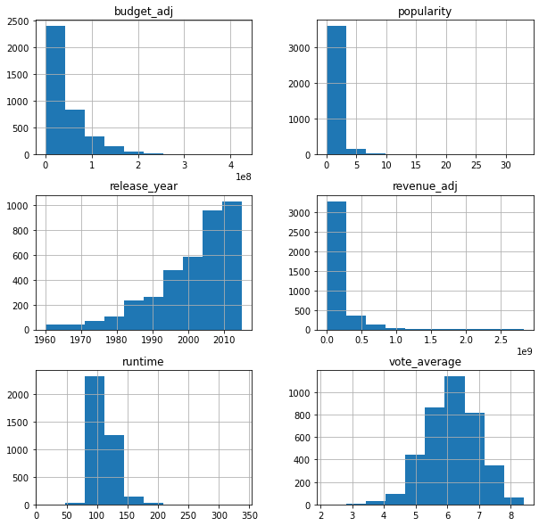

```python
df.hist(figsize=(10, 10));
```

What's next now is to start answering the questions I highlighted earlier on.

1. Which genres are most popualar from year to year
2. Properties associated with movies that have high revenues
- What level of popularity generates the highest revenue?
- How does runtime affect the revenue generated?
- How does vote average affect the revenue generated?
- How does budget affect the revenue generated?
- How does the genre affect the revenue generated?

### Question 1: Which Genres Are Most Popular from Year to Year?

In this section, we'll be exploring the genre and release year columns to see the genres that are most popular from year to year

```python
# Grouping by year and checking out the genre trends
df.groupby('release_year')['main_genre'].max()
```

```
release_year
1960              Drama
1961            Western
1962            Western
1963             Horror
1964              Drama
1965              Drama
1966            Mystery
1967              Music
1968            Western
1969            History
1970            History
1971    Science Fiction
1972              Drama
1973    Science Fiction
```

[output cut: 43 more lines]

Next step is to do a value count to see the most popular genres

```python
# Checking the value counts
most_popular_genres = df.groupby('release_year')['main_genre'].max().value_counts()
most_popular_genres
```

```
Thriller           16
Western            13
War                 8
Science Fiction     6
Drama               4
Horror              3
Mystery             2
History             2
TV Movie            1
Music               1
Name: main_genre, dtype: int64
```

Now, getting the list to plot the bar chart to visualize the data

```python
genre_names = most_popular_genres.keys()
genre_names
```

```
Index(['Thriller', 'Western', 'War', 'Science Fiction', 'Drama', 'Horror',
       'Mystery', 'History', 'TV Movie', 'Music'],
      dtype='object')
```

Now, displaying the visual representation of the most popular genres year by year.

```
Thriller           16
Western            13
War                 8
Science Fiction     6
Drama               4
Horror              3
Mystery             2
History             2
TV Movie            1
Music               1
Name: main_genre, dtype: int64
```

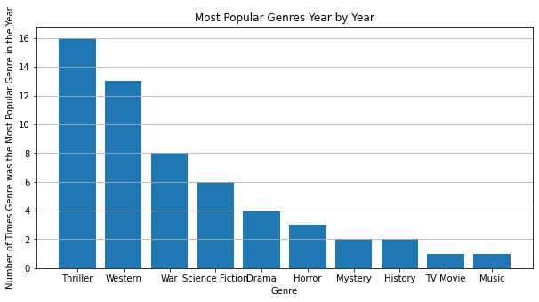

```python
# Including the relevant statistics for this figure
print(most_popular_genres)

# Making the visualization
fig = plt.figure(figsize=(10, 5))
plt.bar(genre_names, most_popular_genres)
plt.xlabel('Genre')
plt.ylabel('Number of Times Genre was the Most Popular Genre in the Year')
plt.title('Most Popular Genres Year by Year')
plt.grid(axis='y')
plt.show()
```

From this, we can conclude that the 3 most popular genres from year to year are Thriller, Western, and War

### Question 2: Properties Associated with Movies That Have High Revenues (With Scatter Plots)

In this section, I'll be checking out how popularity, runtime, vote average, budget, and genre affect revenue

First, I'll be checking out the dataframe

```python
df.head()
```

|  | popularity | director | runtime | vote_average | release_year | budget_adj | revenue_adj | lead_cast | main_genre | main_production_company |
| --- | --- | --- | --- | --- | --- | --- | --- | --- | --- | --- |
| 0 | 32.985763 | Colin Trevorrow | 124 | 6.5 | 2015 | 137999939.3 | 1.392446e+09 | Chris Pratt | Action | Universal Studios |
| 1 | 28.419936 | George Miller | 120 | 7.1 | 2015 | 137999939.3 | 3.481613e+08 | Tom Hardy | Action | Village Roadshow Pictures |
| 2 | 13.112507 | Robert Schwentke | 119 | 6.3 | 2015 | 101199955.5 | 2.716190e+08 | Shailene Woodley | Adventure | Summit Entertainment |
| 3 | 11.173104 | J.J. Abrams | 136 | 7.5 | 2015 | 183999919.0 | 1.902723e+09 | Harrison Ford | Action | Lucasfilm |
| 4 | 9.335014 | James Wan | 137 | 7.3 | 2015 | 174799923.1 | 1.385749e+09 | Vin Diesel | Action | Universal Pictures |

So, we'll be checking out if each of the other colums affects revenue and how it does

### Checking the Correlations

For the numerical data, I'll be checking if the variables have a correlation with the revenue.

I'll start with checking out the correlation between popularity and revenue

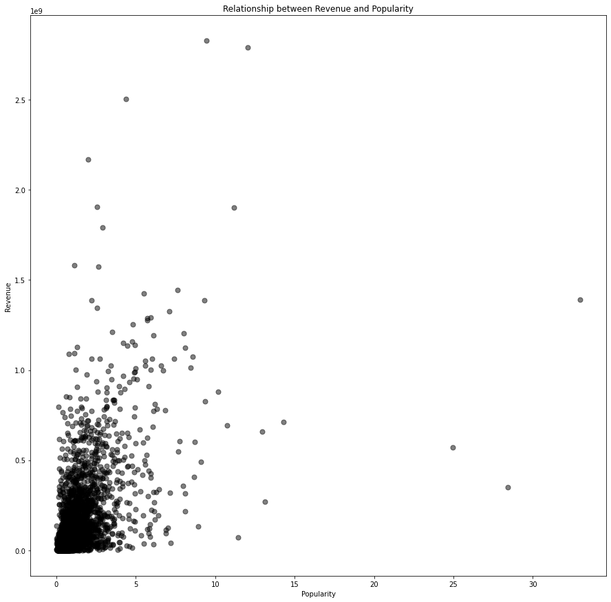

```python
# revenue against popularity
plt.figure(figsize=(15, 15))
plt.scatter(df['popularity'], df['revenue_adj'], s=50, c='black', alpha=0.5)
plt.title('Relationship between Revenue and Popularity')
plt.xlabel('Popularity')
plt.ylabel('Revenue')
plt.show()
```

From this, no deductions can be made probably because of the large dataset we have.

Let's check out the if the other variables have a correlation with revenues using scatter plots before I debunk this method of analysis and visualization.

Now, let's see the correlation between the revenue and runtime

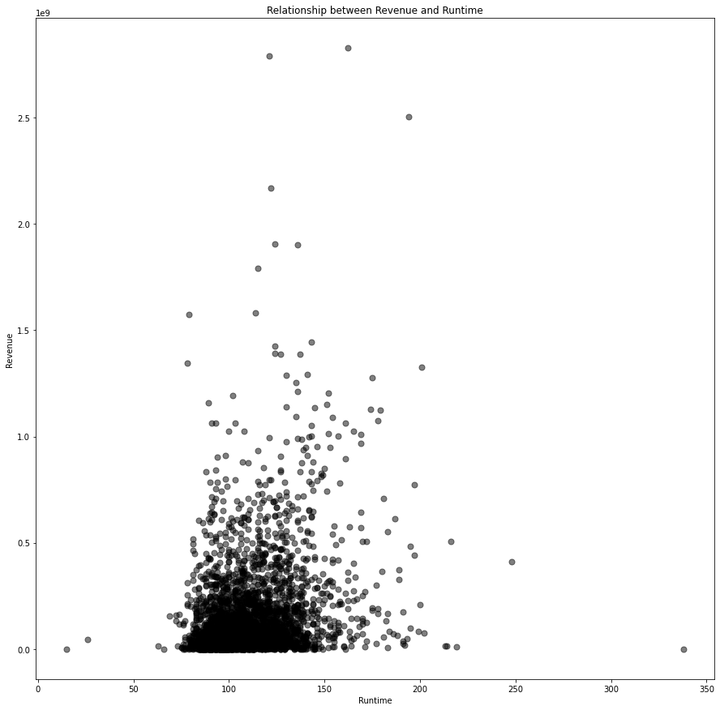

```python
# revenue against runtime
plt.figure(figsize=(15, 15))
plt.scatter(df['runtime'], df['revenue_adj'], s=50, c='black', alpha=0.5)
plt.title('Relationship between Revenue and Runtime')
plt.xlabel('Runtime')
plt.ylabel('Revenue')
plt.show()
```

Still no clear correlation

Now, let's check out the correlation between revenue and vote average

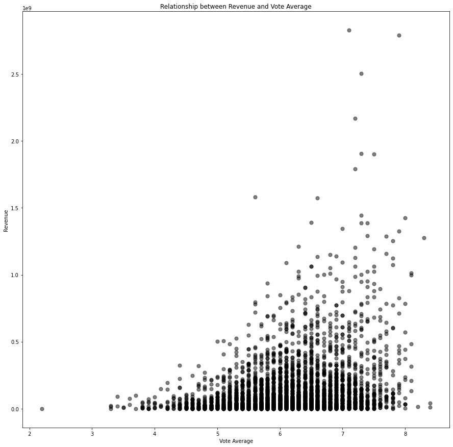

```python
# revenue against vote average

plt.figure(figsize=(15, 15))
plt.scatter(df['vote_average'], df['revenue_adj'], s=50, c='black', alpha=0.5)
plt.title('Relationship between Revenue and Vote Average')
plt.xlabel('Vote Average')
plt.ylabel('Revenue')
plt.show()
```

Seems there's a relationship here but still doesn't have a clear correlation.

Lastly, let's check out the relationship between revenue and budget

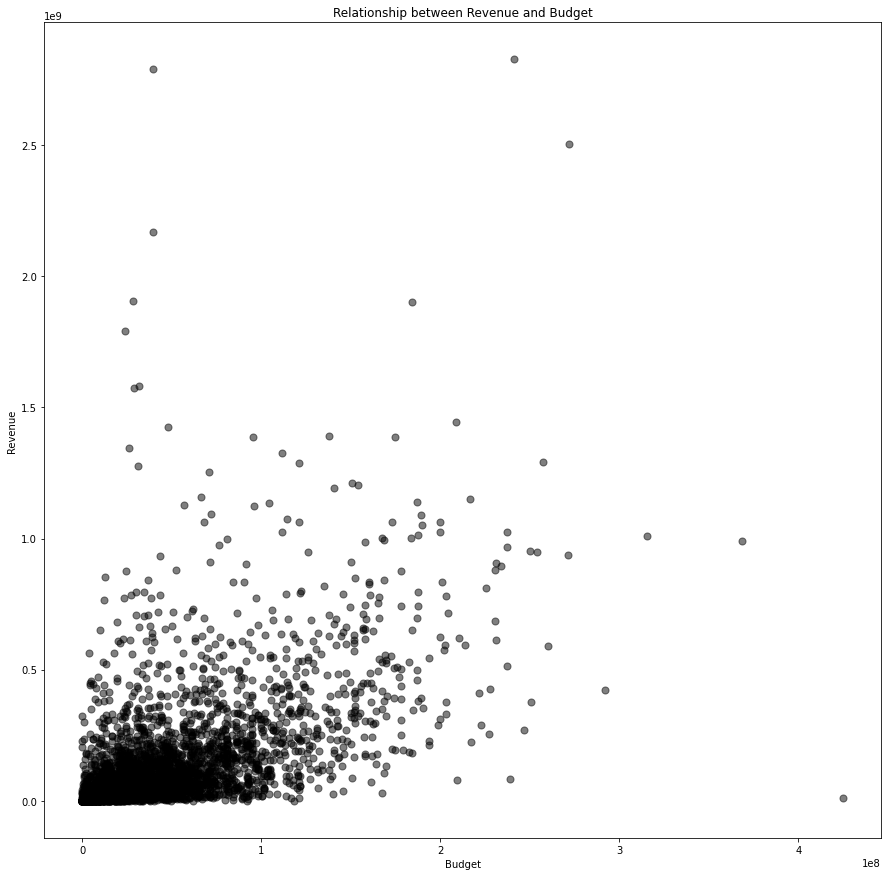

```python
# revenue against budget

plt.figure(figsize=(15, 15))
plt.scatter(df['budget_adj'], df['revenue_adj'], s=50, c='black', alpha=0.5)
plt.title('Relationship between Revenue and Budget')
plt.xlabel('Budget')
plt.ylabel('Revenue')
plt.show()
```

**Conclusion**: Seems scatter plots won't really help. Let's head to bar charts

### Question 2: Properties Associated with Movies That Have High Revenues (With Bar Charts)

In this section we'll be using mean values and grouping the data sets to see the properties associated with movies that have high revenues

First, let's check the general description of the data

```python
# Checking out the overview of the data
df.describe()
```

|  | popularity | runtime | vote_average | release_year | budget_adj | revenue_adj |
| --- | --- | --- | --- | --- | --- | --- |
| count | 3805.000000 | 3805.000000 | 3805.000000 | 3805.000000 | 3.805000e+03 | 3.805000e+03 |
| mean | 1.203784 | 109.351117 | 6.170565 | 2001.229172 | 4.471977e+07 | 1.387159e+08 |
| std | 1.480569 | 19.845678 | 0.792437 | 11.329616 | 4.488697e+07 | 2.169973e+08 |
| min | 0.010335 | 15.000000 | 2.200000 | 1960.000000 | 9.693980e-01 | 2.370705e+00 |
| 25% | 0.470651 | 96.000000 | 5.700000 | 1995.000000 | 1.354637e+07 | 1.925371e+07 |
| 50% | 0.810805 | 106.000000 | 6.200000 | 2004.000000 | 3.038360e+07 | 6.284688e+07 |
| 75% | 1.387163 | 119.000000 | 6.700000 | 2010.000000 | 6.084153e+07 | 1.658054e+08 |
| max | 32.985763 | 338.000000 | 8.400000 | 2015.000000 | 4.250000e+08 | 2.827124e+09 |

### 2A. What level of popularity generates the highest revenue?

In this section, we'll be seeing the level of popularity that generates the highest revenue

First, I'll create a function to take the column name as input and return the chart with relevant statistics

Now, I'll be viewing the min, 25%, 50%, 75% and max popularity with the describe_chart function I created.

```python
def describe_chart(column_name):
    return pd.DataFrame(df[column_name].describe())
```

```python
describe_chart('popularity')
```

|  | popularity |
| --- | --- |
| count | 3805.000000 |
| mean | 1.203784 |
| std | 1.480569 |
| min | 0.010335 |
| 25% | 0.470651 |
| 50% | 0.810805 |
| 75% | 1.387163 |
| max | 32.985763 |

Bin edges that will cut the data into groups

```python
bin_edges_pop = [0.10335, 0.470651, 0.810805, 1.387163, 32.985763]
```

Labels for the four popularity groups.

```python
bin_names_pop = ['Low', 'Moderately Low', 'Moderately High', 'High']
```

Now, I'll be creating the popularity levels column

```python
# Creating the popularity levels column
df['popularity_levels'] = pd.cut(df['popularity'], bin_edges_pop, labels=bin_names_pop)

# Checking for the successful creation of this colum
df.head()
```

|  | popularity | director | runtime | vote_average | release_year | budget_adj | revenue_adj | lead_cast | main_genre | main_production_company | popularity_levels |
| --- | --- | --- | --- | --- | --- | --- | --- | --- | --- | --- | --- |
| 0 | 32.985763 | Colin Trevorrow | 124 | 6.5 | 2015 | 137999939.3 | 1.392446e+09 | Chris Pratt | Action | Universal Studios | High |
| 1 | 28.419936 | George Miller | 120 | 7.1 | 2015 | 137999939.3 | 3.481613e+08 | Tom Hardy | Action | Village Roadshow Pictures | High |
| 2 | 13.112507 | Robert Schwentke | 119 | 6.3 | 2015 | 101199955.5 | 2.716190e+08 | Shailene Woodley | Adventure | Summit Entertainment | High |
| 3 | 11.173104 | J.J. Abrams | 136 | 7.5 | 2015 | 183999919.0 | 1.902723e+09 | Harrison Ford | Action | Lucasfilm | High |
| 4 | 9.335014 | James Wan | 137 | 7.3 | 2015 | 174799923.1 | 1.385749e+09 | Vin Diesel | Action | Universal Pictures | High |

Finding the mean revenue of each popularity level with groupby

```python
mean_groupby_pop = df.groupby('popularity_levels').mean().revenue_adj
mean_groupby_pop
```

```
popularity_levels
Low                4.406673e+07
Moderately Low     6.941361e+07
Moderately High    1.274535e+08
High               3.152176e+08
Name: revenue_adj, dtype: float64
```

This shows that the higher the popularity the higher the revenue generated. Now, let's visualize this with a bar chart

Next, plottting the bar chart with matplotlib to show the visual representation

```
popularity_levels
Low                4.406673e+07
Moderately Low     6.941361e+07
Moderately High    1.274535e+08
High               3.152176e+08
Name: revenue_adj, dtype: float64
```

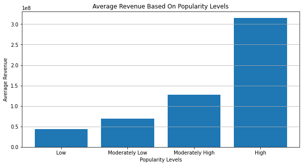

```python
# Including the relevant statistics for this figure
print(mean_groupby_pop)

# Making the visualization
fig = plt.figure(figsize=(10, 5))
plt.bar(bin_names_pop, mean_groupby_pop)
plt.xlabel('Popularity Levels')
plt.ylabel('Average Revenue')
plt.title('Average Revenue Based On Popularity Levels')
plt.grid(axis='y')
plt.show()
```

**Conclusion**: This bar chart shows that movies that have popularity levels from 1.387163(75%) to 32.985763(max) generate higher revenues

### 2B. How does Runtime affect the Revenue generated?

In this section, we'll be seeing how runtime affects the revenue generated by movies

First, I'll be viewing the min, 25%, 50%, 75%, and max runtime with the describe_chart function I created.

```python
describe_chart('runtime')
```

|  | runtime |
| --- | --- |
| count | 3805.000000 |
| mean | 109.351117 |
| std | 19.845678 |
| min | 15.000000 |
| 25% | 96.000000 |
| 50% | 106.000000 |
| 75% | 119.000000 |
| max | 338.000000 |

Making bin edges that will be used to cut the data into groups

```python
bin_edges_runtime = [15.0, 96.0, 106.0, 119.0, 338.0]
```

```python
bin_names_runtime = ['Short', 'Moderately Short', 'Moderately Long', 'Long']
```

For clarification purposes:

- Short ranges from min to 25%
- Moderately Short ranges from 25% to 50%
- Moderately Long ranges from 50% to 75%
- Long ranges from 75% to max

Next step is Creating runtime_levels column

```python
df['runtime_levels'] = pd.cut(df['runtime'], bin_edges_runtime, labels=bin_names_runtime)

df.head()
```

|  | popularity | director | runtime | vote_average | release_year | budget_adj | revenue_adj | lead_cast | main_genre | main_production_company | popularity_levels | runtime_levels |
| --- | --- | --- | --- | --- | --- | --- | --- | --- | --- | --- | --- | --- |
| 0 | 32.985763 | Colin Trevorrow | 124 | 6.5 | 2015 | 137999939.3 | 1.392446e+09 | Chris Pratt | Action | Universal Studios | High | Long |
| 1 | 28.419936 | George Miller | 120 | 7.1 | 2015 | 137999939.3 | 3.481613e+08 | Tom Hardy | Action | Village Roadshow Pictures | High | Long |
| 2 | 13.112507 | Robert Schwentke | 119 | 6.3 | 2015 | 101199955.5 | 2.716190e+08 | Shailene Woodley | Adventure | Summit Entertainment | High | Moderately Long |
| 3 | 11.173104 | J.J. Abrams | 136 | 7.5 | 2015 | 183999919.0 | 1.902723e+09 | Harrison Ford | Action | Lucasfilm | High | Long |
| 4 | 9.335014 | James Wan | 137 | 7.3 | 2015 | 174799923.1 | 1.385749e+09 | Vin Diesel | Action | Universal Pictures | High | Long |

Then, finding the mean of the popularity levels

```python
runtime_groupby_mean = df.groupby('runtime_levels').mean().revenue_adj
runtime_groupby_mean
```

```
runtime_levels
Short               9.621780e+07
Moderately Short    9.580482e+07
Moderately Long     1.293805e+08
Long                2.378789e+08
Name: revenue_adj, dtype: float64
```

Now, plottting the bar chart with matplotlib to show the visual representation

```
runtime_levels
Short               9.621780e+07
Moderately Short    9.580482e+07
Moderately Long     1.293805e+08
Long                2.378789e+08
Name: revenue_adj, dtype: float64
```

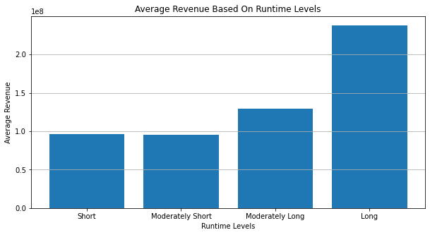

```python
# Including the relevant statistics for this figure
print(runtime_groupby_mean)

# Making the visualization
fig = plt.figure(figsize=(10, 5))
plt.bar(bin_names_runtime, runtime_groupby_mean)
plt.xlabel('Runtime Levels')
plt.ylabel('Average Revenue')
plt.title('Average Revenue Based On Runtime Levels')
plt.grid(axis='y')
plt.show()
```

**Conclusion**: It can be seen from the bar chart above that longer movies(movies that have runtime that range from 119 minutes (75%) to 338 minutes (max)) generate more revenue

### 2C. How Does Vote Average Affect The Revenue Generated?

In this section, I'll be analyzing and visualizing how vote average affects the revenue generated.

First, I'll be viewing the min, 25%, 50%, 75%, max vote_average values with the describe_chart function I created.

```python
describe_chart('vote_average')
```

|  | vote_average |
| --- | --- |
| count | 3805.000000 |
| mean | 6.170565 |
| std | 0.792437 |
| min | 2.200000 |
| 25% | 5.700000 |
| 50% | 6.200000 |
| 75% | 6.700000 |
| max | 8.400000 |

Creating Bin edges that will be used to "cut" the data into groups

```python
bin_edges_vote = [2.2, 5.7, 6.2, 6.7, 8.4]
```

Creating Labels for the four vote levels

```python
bin_names_vote = ['Low', 'Moderately Low', 'Moderately High', 'High']
```

For clarification purposes:

- Low ranges from min to 25%
- Moderately Low ranges from 25% to 50%
- Moderately High ranges from 50% to 75%
- High ranges from 75% to max

```python
df['vote_average_levels'] = pd.cut(df['vote_average'], bin_edges_vote, labels=bin_names_vote)
```

```python
df.head()
```

|  | popularity | director | runtime | vote_average | release_year | budget_adj | revenue_adj | lead_cast | main_genre | main_production_company | popularity_levels | runtime_levels | vote_average_levels |
| --- | --- | --- | --- | --- | --- | --- | --- | --- | --- | --- | --- | --- | --- |
| 0 | 32.985763 | Colin Trevorrow | 124 | 6.5 | 2015 | 137999939.3 | 1.392446e+09 | Chris Pratt | Action | Universal Studios | High | Long | Moderately High |
| 1 | 28.419936 | George Miller | 120 | 7.1 | 2015 | 137999939.3 | 3.481613e+08 | Tom Hardy | Action | Village Roadshow Pictures | High | Long | High |
| 2 | 13.112507 | Robert Schwentke | 119 | 6.3 | 2015 | 101199955.5 | 2.716190e+08 | Shailene Woodley | Adventure | Summit Entertainment | High | Moderately Long | Moderately High |
| 3 | 11.173104 | J.J. Abrams | 136 | 7.5 | 2015 | 183999919.0 | 1.902723e+09 | Harrison Ford | Action | Lucasfilm | High | Long | High |
| 4 | 9.335014 | James Wan | 137 | 7.3 | 2015 | 174799923.1 | 1.385749e+09 | Vin Diesel | Action | Universal Pictures | High | Long | High |

The next thing to do is to find the mean revenue of each vote_average

```python
vote_groupby_mean = df.groupby('vote_average_levels').mean().revenue_adj
vote_groupby_mean
```

```
vote_average_levels
Low                7.756931e+07
Moderately Low     1.220308e+08
Moderately High    1.442703e+08
High               2.251243e+08
Name: revenue_adj, dtype: float64
```

Now, Plottting the bar chart with matplotlib to show the visual representation

```
vote_average_levels
Low                7.756931e+07
Moderately Low     1.220308e+08
Moderately High    1.442703e+08
High               2.251243e+08
Name: revenue_adj, dtype: float64
```

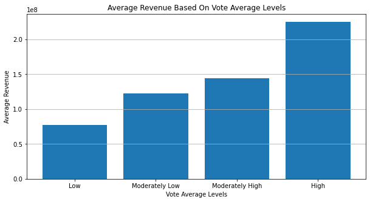

```python
# Including the relevant statistics for this figure
print(vote_groupby_mean)

# Making the visualization
fig = plt.figure(figsize=(10, 5))
plt.bar(bin_names_vote, vote_groupby_mean)
plt.xlabel('Vote Average Levels')
plt.ylabel('Average Revenue')
plt.title('Average Revenue Based On Vote Average Levels')
plt.grid(axis='y')
plt.show()
```

**Conclusion**: This clearly shows a positive correlation between vote average and revenue generated

### 2D. How does Budget affect the Revenue Generated?

In this section, I'll be analyzing and visualizing how the budget affects the revenue generated.

Let's start by viewing the min, 25%, 50%, 75%, max budget values with the describe_chart function I created.

```python
describe_chart('budget_adj')
```

|  | budget_adj |
| --- | --- |
| count | 3.805000e+03 |
| mean | 4.471977e+07 |
| std | 4.488697e+07 |
| min | 9.693980e-01 |
| 25% | 1.354637e+07 |
| 50% | 3.038360e+07 |
| 75% | 6.084153e+07 |
| max | 4.250000e+08 |

Creating bin edges that will be used to cut the data into groups

```python
bin_edges_budget = [9.693980e-01, 1.354637e+07, 3.038360e+07, 6.084153e+07, 4.250000e+08]
```

Making labels for the four budget level groups

```python
bin_names_budget = ['Low', 'Moderately Low', 'Moderately High', 'High']
```

For clarification purposes:

- Low ranges from min to 25%
- Moderately Low ranges from 25% to 50%
- Moderately High ranges from 50% to 75%
- High ranges from 75% to max

Creating a column for budget levels and checking if it was successfully created.

```python
# Creating budget_levels column
df['budget_levels'] = pd.cut(df['budget_adj'], bin_edges_budget, labels=bin_names_budget)

# Checks for successful creation of this column
df.head()
```

|  | popularity | director | runtime | vote_average | release_year | budget_adj | revenue_adj | lead_cast | main_genre | main_production_company | popularity_levels | runtime_levels | vote_average_levels | budget_levels |
| --- | --- | --- | --- | --- | --- | --- | --- | --- | --- | --- | --- | --- | --- | --- |
| 0 | 32.985763 | Colin Trevorrow | 124 | 6.5 | 2015 | 137999939.3 | 1.392446e+09 | Chris Pratt | Action | Universal Studios | High | Long | Moderately High | High |
| 1 | 28.419936 | George Miller | 120 | 7.1 | 2015 | 137999939.3 | 3.481613e+08 | Tom Hardy | Action | Village Roadshow Pictures | High | Long | High | High |
| 2 | 13.112507 | Robert Schwentke | 119 | 6.3 | 2015 | 101199955.5 | 2.716190e+08 | Shailene Woodley | Adventure | Summit Entertainment | High | Moderately Long | Moderately High | High |
| 3 | 11.173104 | J.J. Abrams | 136 | 7.5 | 2015 | 183999919.0 | 1.902723e+09 | Harrison Ford | Action | Lucasfilm | High | Long | High | High |
| 4 | 9.335014 | James Wan | 137 | 7.3 | 2015 | 174799923.1 | 1.385749e+09 | Vin Diesel | Action | Universal Pictures | High | Long | High | High |

Now, I'll be Finding the mean revenue level with groupby

```python
budget_groupby_mean = df.groupby('budget_levels').mean().revenue_adj
budget_groupby_mean
```

```
budget_levels
Low                4.028880e+07
Moderately Low     7.912161e+07
Moderately High    1.312331e+08
High               3.044054e+08
Name: revenue_adj, dtype: float64
```

The next step is to plot the bar chart with matplotlib to show the visual representation

```
budget_levels
Low                4.028880e+07
Moderately Low     7.912161e+07
Moderately High    1.312331e+08
High               3.044054e+08
Name: revenue_adj, dtype: float64
```

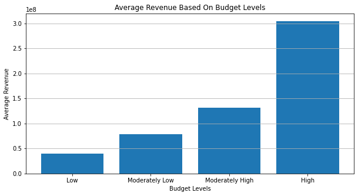

```python
# Including the relevant statistics for this figure
print(budget_groupby_mean)

# Making the visualization
fig = plt.figure(figsize=(10, 5))
plt.bar(bin_names_budget, budget_groupby_mean)
plt.xlabel('Budget Levels')
plt.ylabel('Average Revenue')
plt.title('Average Revenue Based On Budget Levels')
plt.grid(axis='y')
plt.show()
```

**Conclusion**: This shows that movies with higher budget generate higher revenue

Checking the overview of dataframe to see what other relationship I can explore

```python
df.head()
```

|  | popularity | director | runtime | vote_average | release_year | budget_adj | revenue_adj | lead_cast | main_genre | main_production_company | popularity_levels | runtime_levels | vote_average_levels | budget_levels |
| --- | --- | --- | --- | --- | --- | --- | --- | --- | --- | --- | --- | --- | --- | --- |
| 0 | 32.985763 | Colin Trevorrow | 124 | 6.5 | 2015 | 137999939.3 | 1.392446e+09 | Chris Pratt | Action | Universal Studios | High | Long | Moderately High | High |
| 1 | 28.419936 | George Miller | 120 | 7.1 | 2015 | 137999939.3 | 3.481613e+08 | Tom Hardy | Action | Village Roadshow Pictures | High | Long | High | High |
| 2 | 13.112507 | Robert Schwentke | 119 | 6.3 | 2015 | 101199955.5 | 2.716190e+08 | Shailene Woodley | Adventure | Summit Entertainment | High | Moderately Long | Moderately High | High |
| 3 | 11.173104 | J.J. Abrams | 136 | 7.5 | 2015 | 183999919.0 | 1.902723e+09 | Harrison Ford | Action | Lucasfilm | High | Long | High | High |
| 4 | 9.335014 | James Wan | 137 | 7.3 | 2015 | 174799923.1 | 1.385749e+09 | Vin Diesel | Action | Universal Pictures | High | Long | High | High |

### 2E. How Does The Genre Affect The Revenue Generated?

In this section, I'll be analyzing how genre affects the revenue generated.

I'll start by Grouping by main genre and finding the mean of the revenue for each group

```python
df.groupby('main_genre').mean().revenue_adj
```

```
main_genre
Action             1.636927e+08
Adventure          3.059644e+08
Animation          3.012466e+08
Comedy             1.020823e+08
Crime              9.841484e+07
Documentary        3.074447e+07
Drama              9.235306e+07
Family             2.728411e+08
Fantasy            1.960532e+08
History            1.680665e+08
Horror             7.945503e+07
Music              1.285718e+08
Mystery            8.748986e+07
Romance            1.261528e+08
Science Fiction    2.171706e+08
TV Movie           5.838910e+07
Thriller           9.109040e+07
War                1.405774e+08
Western            1.158031e+08
Name: revenue_adj, dtype: float64
```

To have a better look at the standings, I'll be sorting it out from the highest revenue average to the lowest.

```python
mean_group_genre = df.groupby('main_genre').mean().revenue_adj.sort_values(ascending=False)
mean_group_genre
```

```
main_genre
Adventure          3.059644e+08
Animation          3.012466e+08
Family             2.728411e+08
Science Fiction    2.171706e+08
Fantasy            1.960532e+08
History            1.680665e+08
Action             1.636927e+08
War                1.405774e+08
Music              1.285718e+08
Romance            1.261528e+08
Western            1.158031e+08
Comedy             1.020823e+08
Crime              9.841484e+07
Drama              9.235306e+07
Thriller           9.109040e+07
Mystery            8.748986e+07
Horror             7.945503e+07
TV Movie           5.838910e+07
Documentary        3.074447e+07
Name: revenue_adj, dtype: float64
```

Getting the list to plot the bar chart to visualize the data

```python
genre_keys = mean_group_genre.keys()
genre_keys
```

```
Index(['Adventure', 'Animation', 'Family', 'Science Fiction', 'Fantasy',
       'History', 'Action', 'War', 'Music', 'Romance', 'Western', 'Comedy',
       'Crime', 'Drama', 'Thriller', 'Mystery', 'Horror', 'TV Movie',
       'Documentary'],
      dtype='object', name='main_genre')
```

Now, the visual representation of the average revenue based on Genre

```
main_genre
Adventure          3.059644e+08
Animation          3.012466e+08
Family             2.728411e+08
Science Fiction    2.171706e+08
Fantasy            1.960532e+08
History            1.680665e+08
Action             1.636927e+08
War                1.405774e+08
Music              1.285718e+08
Romance            1.261528e+08
Western            1.158031e+08
Comedy             1.020823e+08
Crime              9.841484e+07
Drama              9.235306e+07
Thriller           9.109040e+07
Mystery            8.748986e+07
Horror             7.945503e+07
TV Movie           5.838910e+07
Documentary        3.074447e+07
Name: revenue_adj, dtype: float64
```

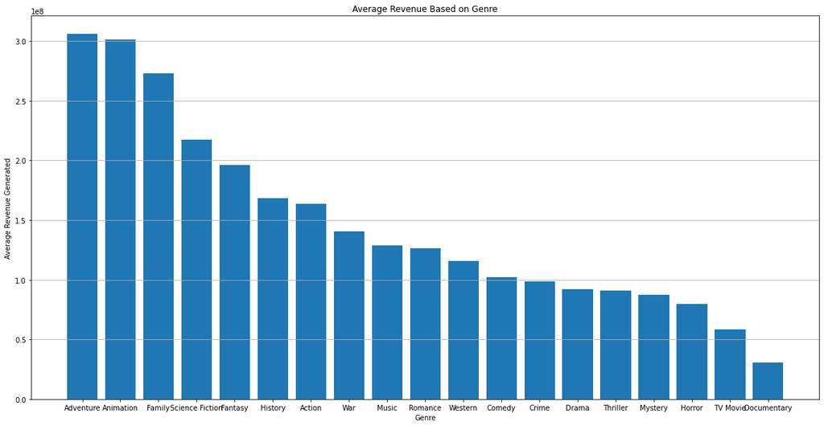

```python
# Including the relevant statistics for this figure
print(mean_group_genre)

# Making the visualization
fig = plt.figure(figsize=(20, 10))
plt.bar(genre_keys, mean_group_genre)
plt.xlabel('Genre')
plt.ylabel('Average Revenue Generated')
plt.title('Average Revenue Based on Genre')
plt.grid(axis='y')
plt.show()
```

**Conclusion**: From this, we can deduce that genres like Adventure, Animation, Family, and Science Fiction generally generate more revenue than others

## Conclusions

After the analysis and visualizations made, it can be conluded that (from the data set):

1. Thriller, Western, and War are the most popular genres year to year
2. Properties associated with movies that have high revenues include:
   - High Level of popularity
   - Long Runtimes
   - High Vote Averages
   - High Budget

## Limitations

1. I had to drop a lot of data rows as they had 0 values in budget and revenue columns
2. High and Long are relative qualifiers but in the context of this analysis, it can be regarded as quantities that are in the range 75% to the max of their distribution